# SuperMap tutorial

In this tutorial, we demonstrate how to use SuperMap for integrative analyses of unpaired single-cell multimodal data. Here, we showcase an example of integrating protein and ATAC modality. We use an ASAP-seq dataset downloaded from GEO (accession ID: GSE156478), which contains antibody-derived tag measurements for 227 proteins along with genome-wide chromatin accessibility profiles.

## Necessary packages

To run this vignette, please ensure that the following packages are installed:

```r
library(SuperMap)
library(Seurat)
library(Signac)
library(GenomicRanges)
library(GenomeInfoDb)
library(EnsDb.Hsapiens.v86)
```

## Stage 1: Data Preparation

We begin by loading the downloaded data, which includes ADT and scATAC-seq measurements.

```r
## Read data from the file
atac_count = readRDS('ASAP_data/atac_count.RDS')
adt_matrix = readRDS('ASAP_data/adt_matrix.RDS')
```

First, we create separate Seurat objects for the ADT and ATAC data, and then perform preprocessing for each modality.

```r
adt_seurat = CreateSeuratObject(counts = t(adt_matrix),assay = 'ADT')

chrom_assay <- CreateChromatinAssay(
  counts = atac_count,
  sep = c("-", "-"),
  fragments = "ASAP_data/GSM4732109_CD28_CD3_control_ASAP_fragments.tsv.gz")
```

```
## Computing hash
```

```r
atac_seurat <- CreateSeuratObject(counts = chrom_assay,assay = "ATAC")
```

Next, we perform data normalization and dimensional reduction for visualization, following the Seurat workflow. If you are unfamiliar with this workflow, please refer to their official tutorial.

```r
adt_seurat = NormalizeData(adt_seurat)
```

```
## Normalizing layer: counts
```

```r
adt_seurat = ScaleData(adt_seurat)
adt_seurat = RunPCA(adt_seurat,features = rownames(adt_seurat),verbose = FALSE)
adt_seurat = RunUMAP(adt_seurat,dims = 1:50)
adt_seurat = FindNeighbors(object = adt_seurat, reduction = 'pca', dims = 1:50)
atac_seurat <- RunTFIDF(atac_seurat)
```

```
## Performing TF-IDF normalization
```

```r
atac_seurat <- FindTopFeatures(atac_seurat, min.cutoff = 'q0')
atac_seurat <- RunSVD(atac_seurat)
```

```
## Running SVD
## Scaling cell embeddings
```

```r
atac_seurat <- RunUMAP(atac_seurat, reduction = 'lsi', dims = 2:50)
atac_seurat <- FindNeighbors(object = atac_seurat, reduction = 'lsi', dims = 2:50)
```

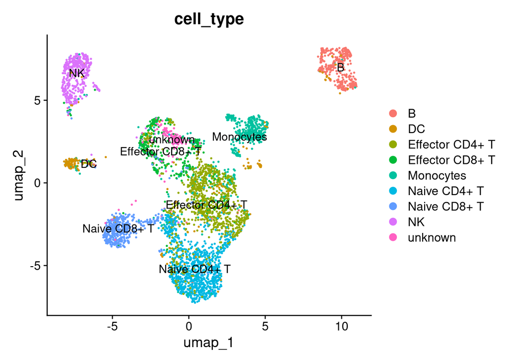

```r
cell_type= read.csv('ASAP_data/asapseq_control_cellTypes.csv')
atac_seurat$cell_type = cell_type$x
DimPlot(atac_seurat,reduction = 'umap',label = TRUE,group.by = 'cell_type')
```

At this point, we have obtained two preprocessed Seurat objects—one for each modality—which are ready for the subsequent computational analyses.

## Stage 2: Meta-cell partitioning

In practice, single-cell data are highly sparse and noisy, with an inherently low signal-to-noise ratio. This poses challenges for both model fitting and imputation, making it difficult for the model to capture reliable predictive signals. To address this, SuperMap adopts meta-cell partitioning strategy, a widely used approach to enhance the signal-to-noise ratio in single-cell data by aggregating closely similar cells into meta-cells. For more details, please refer to our paper. Next, we demonstrate how to construct the meta-cell data.

```r
adt_seurat = metacell_construct(object = adt_seurat, resolution = 15, graph.name = 'ADT_snn')
```

```
## Modularity Optimizer version 1.3.0 by Ludo Waltman and Nees Jan van Eck
##
## Number of nodes: 4502
## Number of edges: 189382
##
## Running Louvain algorithm...
## Maximum modularity in 10 random starts: 0.1991
## Number of communities: 117
## Elapsed time: 0 seconds
```

```
## 2 singletons identified. 115 final clusters.
```

```r
atac_seurat = metacell_construct(object = atac_seurat, resolution = 15, graph.name = 'ATAC_snn')
```

```
## Modularity Optimizer version 1.3.0 by Ludo Waltman and Nees Jan van Eck
##
## Number of nodes: 4502
## Number of edges: 183725
##
## Running Louvain algorithm...
## Maximum modularity in 10 random starts: 0.3526
## Number of communities: 100
## Elapsed time: 0 seconds
```

```
## 4 singletons identified. 96 final clusters.
```

The resolution parameter in *metacell_construct* function can be adjusted flexibly, as it determines the graining level of the resulting meta-cells. Meta-cell graining levels within a reasonable range (25–105) are generally feasible. For more details, please refer to our paper.

```r
metacell_adt <- metacell_matrix_ADT(object = adt_seurat,cluster.name = "seurat_clusters")
metacell_atac <- metacell_matrix_ATAC(object = atac_seurat,cluster.name = "seurat_clusters")
```

At this point, we obtained meta-cell data for model fitting to estimate cross-modal mappings.

## Stage 3: Computing peak-protein genomic distance

SuperMap incorporates genomic proximity as prior knowledge to regularize the model. Therefore, we need to compute the genomic distances between protein-coding genes in the ADT modality and peaks in the ATAC modality. As a first step, we convert the protein names to their corresponding gene names.

```r
rna_protein_conversion = read.csv(file = 'ASAP_data/rna_protein_correspondence.txt',header = FALSE, sep = ',')

adt_name = sub("^ADT-", "", colnames(metacell_adt))
colnames(metacell_adt) = adt_name
rna_protein_conversion = rna_protein_conversion[rna_protein_conversion$V2 %in% adt_name,]
metacell_adt = metacell_adt[,rna_protein_conversion$V2]
colnames(metacell_adt) = rna_protein_conversion$V1

gene_annotation = read.table('~/pbmc_pair_cpm/GRCh38_cellranger2020.gene_location.txt',sep = ' ',header = TRUE)   ## Read the genomic coordinates of all genes.
head(gene_annotation)
```

```
##    Chr  start    end           ensID   gene_name strand
## 1 chr1  29554  31109 ENSG00000243485 MIR1302-2HG      +
## 2 chr1  34554  36081 ENSG00000237613     FAM138A      -
## 3 chr1  65419  71585 ENSG00000186092       OR4F5      +
## 4 chr1  89295 133723 ENSG00000238009  AL627309.1      -
## 5 chr1  89551  91105 ENSG00000239945  AL627309.3      -
## 6 chr1 139790 140339 ENSG00000239906  AL627309.2      -
```

```r
supermap_data = gene_peak_distance(rna = metacell_adt, atac = metacell_atac,gene_annotation = gene_annotation)
```

## Stage 4: Model fitting for estimating cross-modal mappings

At this stage, we fit the model to learn the cross-modal mappings using the preprocessed data generated above.

```r
learned_mappings = supermap(input_data = supermap_data)
```

The returned results include both the model’s convergence information and the estimated parameters. We first visualize the convergence curve from this run to examine the iteration process.

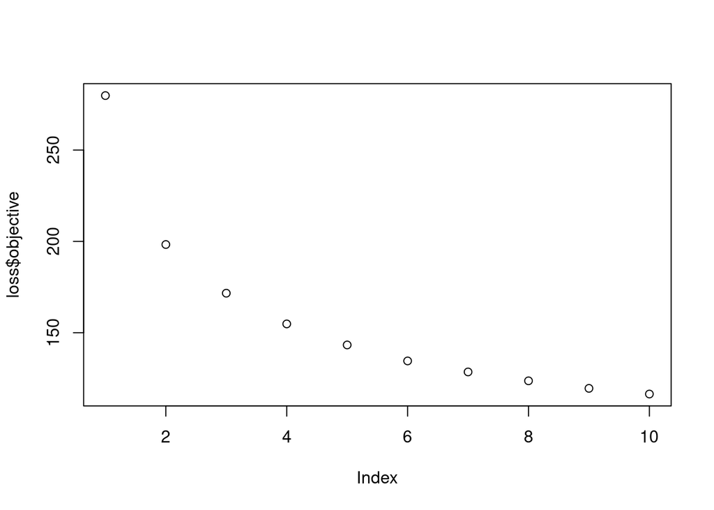

```r
loss = learned_mappings$convergence
loss = as.data.frame(loss)

colnames(loss) = c('residual','objective')
loss$iter = c(1:nrow(loss))

plot(loss$objective)
```

We observed that the objective function steadily converged over iterations.

## Stage 4: Imputating missing-modality profiles

After estimating B, we proceed to impute the missing (unmeasured) modality profiles in unpaired data for subsequent analyses. For imputation, SuperMap provides options at both meta-cell and single-cell resolution to accommodate different downstream analysis tasks (see our paper for details). Below, we demonstrate how to predict protein abundance from chromatin accessibility.

```r
## Meta-cell imputation
imputation_metacell = imputation(supermap_data = supermap_data, learned_mappings = learned_mappings, atac_data = atac_seurat, resolution = 'meta-cell')

##Single-cell imputation
imputation_singlecell = imputation(supermap_data = supermap_data, learned_mappings = learned_mappings, atac_data = atac_seurat, resolution = 'single-cell')
```

The imputed profiles enable a wide range of downstream analyses of unpaired data, including cell annotation, diagonal integration, regulatory inference, and trajectory analysis. Next, we visualize the imputed expression patterns of several representative marker genes to facilitate cell annotation.

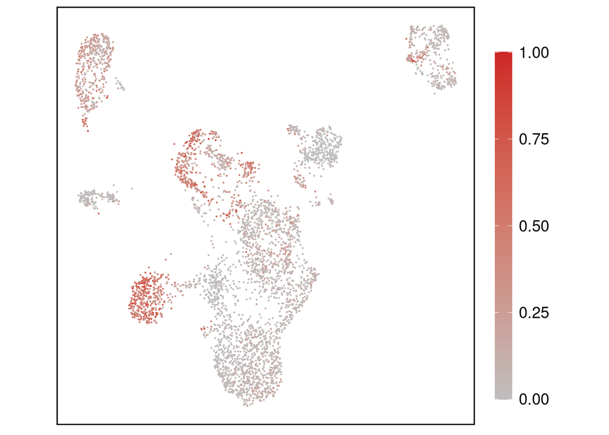

```r
cell_umap = atac_seurat@reductions$umap@cell.embeddings
cell_umap = as.data.frame(cell_umap)

cell_umap$imputed_value = imputation_singlecell[rownames(cell_umap),'CD8B']
marker_plot(cell_umap = cell_umap)
```

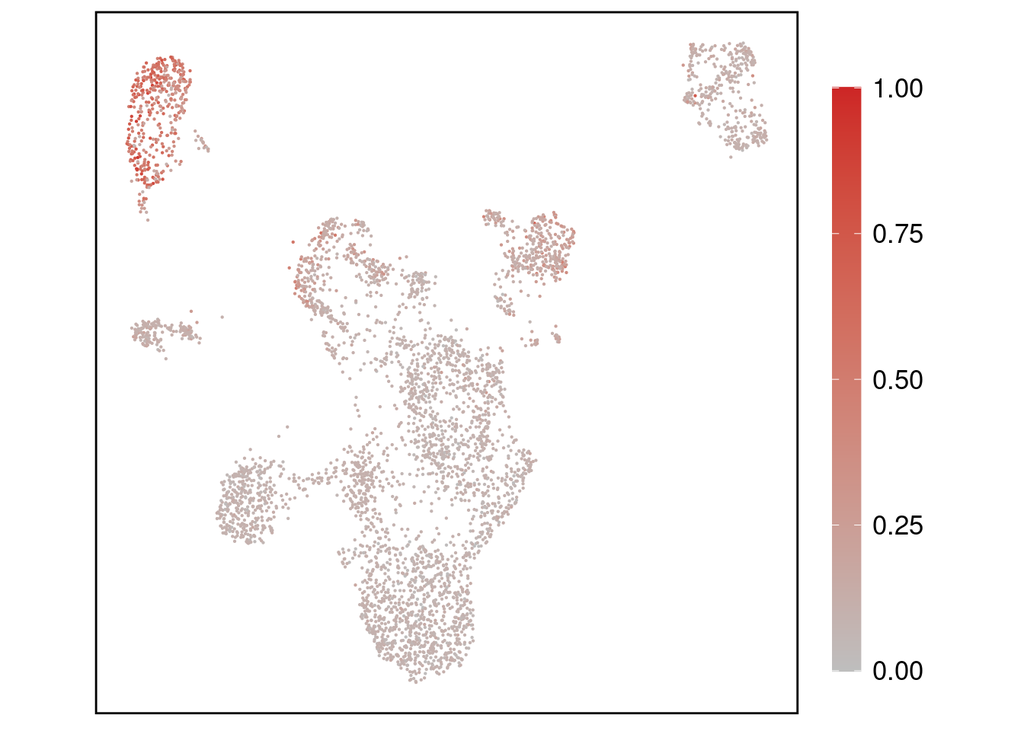

```r
cell_umap$imputed_value = imputation_singlecell[rownames(cell_umap),'NCR1']
marker_plot(cell_umap = cell_umap)
```

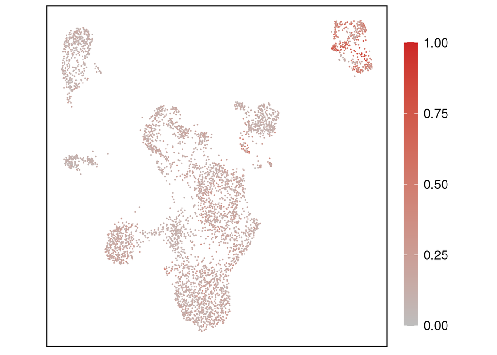

```r
cell_umap$imputed_value = imputation_singlecell[rownames(cell_umap),'CXCR5']
marker_plot(cell_umap = cell_umap)
```